# Introduction to the sail package

Sahir Rai Bhatnagar

2019-12-04

`sail` is a package that fits a linear model with non-linear interactions via penalized maximum likelihood. The regularization path is computed at a grid of values for the regularization parameter $\lambda$ and a fixed value of the second regularization parameter $\alpha$. The method enforces the strong heredity property, i.e., an interaction is selected only if its corresponding main effects are also included. The interactions are limited to a single exposure variable, i.e., $y \sim e + x_1 + x_2 + e*x_1 + e*x_2 + \epsilon$. Furthermore, this package allows a user-defined basis expansion on the $x$ variables to allow for non-linear effects. The default is bsplines (e.g. `splines::bs(x, 5)`). It currently only fits linear models (binomial models are due in the next release).

## Model

Let $Y=(Y_1, \ldots, Y_n) \in \mathbb{R}^n$ be a continuous outcome variable, a binary or continuous environment vector, a matrix of predictors, and $\varepsilon = (\varepsilon_1, \ldots, \varepsilon_n) \in \mathbb{R}^n$ a vector of i.i.d random variables with mean 0. Furthermore let $f_j: \mathbb{R} \rightarrow \mathbb{R}$ be a smoothing method for variable $X_j$ by a projection on to a set of basis functions:
$$\begin{equation}
f_j(X_j) = \sum_{\ell = 1}^{m_j} \psi_{j\ell}(X_j) \beta_{j\ell} \label{eq:smooth}
\end{equation}$$
Here, the $\left\lbrace \psi_{j\ell} \right\rbrace_1^{m_j}$ are a family of basis functions in $X_j$~. Let $\boldsymbol{\Psi}_j$ be the $n \times m_j$ matrix of evaluations of the $\psi_{j\ell}$ and for $j = 1, \ldots, p$, i.e., $\boldsymbol{\theta}_j$ is a $m_j$-dimensional column vector of basis coefficients for the $j$th main effect. In this article we consider an additive interaction regression model of the form
$$\begin{align}
Y & = \beta_0 \cdot \boldsymbol{1} + \sum_{j=1}^p \boldsymbol{\Psi}_j \boldsymbol{\theta}_j + \beta_E X_E + \sum_{j=1}^p (X_E \circ \boldsymbol{\Psi}_j) \boldsymbol{\alpha}_{j} + \varepsilon \label{eq:linpred}
\end{align}$$
where $\beta_0$ is the intercept, $\beta_E$ is the coefficient for the environment variable, $\boldsymbol{\alpha}_j = (\alpha_{j1}, \ldots, \alpha_{jm_j})\in \mathbb{R}^{m_j}$ are the basis coefficients for the $j$th interaction term and $(X_E \circ \boldsymbol{\Psi}_j)$ is the $n \times m_j$ matrix formed by the component-wise multiplication of the column vector $X_E$ by each column of $\boldsymbol{\Psi}_j$. To enforce the strong heredity property, we reparametrize the coefficients for the interaction terms in~ as $\boldsymbol{\alpha}_{j} = \gamma_{j} \beta_E \boldsymbol{\theta}_j$:
$$\begin{align}
Y & = \beta_0 \cdot \boldsymbol{1} + \sum_{j=1}^p \boldsymbol{\Psi}_j \boldsymbol{\theta}_j + \beta_E X_E + \sum_{j=1}^p \gamma_{j} \beta_E (X_E \circ \boldsymbol{\Psi}_j) \boldsymbol{\theta}_j + \varepsilon \label{eq:linpred2}
\end{align}$$
For a continuous response, we use the squared-error loss:
$$\begin{equation}
\mathcal{L}(Y;\boldsymbol{\theta}) = \frac{1}{2n}\lVert Y - \beta_0 \cdot \boldsymbol{1} - \sum_{j=1}^p \boldsymbol{\Psi}_j \boldsymbol{\theta}_j - \beta_E X_E - \sum_{j=1}^p \gamma_{j} \beta_E (X_E \circ \boldsymbol{\Psi}_j) \boldsymbol{\theta}_j \rVert_2^2
\end{equation}$$
where $\boldsymbol{\theta} \equiv (\beta_0, \beta_E,\boldsymbol{\theta}_1, \ldots, \boldsymbol{\theta}_p, \gamma_1, \ldots, \gamma_p)$.

We consider the following penalized least squares criterion for this problem:
$$\begin{equation}
\arg\min_{\boldsymbol{\theta} } \mathcal{L}(Y;\boldsymbol{\theta}) + \lambda (1-\alpha) \left( w_E |\beta_E| + \sum_{j=1}^{p} w_j \lVert\boldsymbol{\theta}_j \rVert_2 \right) + \lambda\alpha \sum_{j=1}^{p} w_{jE} |\gamma_{j}| \label{eq:lassolikelihood3}
\end{equation}$$
where $\lambda >0$ and $\alpha \in (0,1)$ are tuning parameters and $w_E, w_j, w_{jE}$ are adaptive weights for $j=1, \ldots, p$. These weights serve as a way of allowing parameters to be penalized differently.

## Installation

The package can be installed from [GitHub](https://github.com/sahirbhatnagar/sail) via

```r
install.packages("pacman")
pacman::p_load_gh('sahirbhatnagar/sail')
```

## Quick Start

We give a quick overview of the main functions and go into details in other vignettes. We will use the simulated data which ships with the package and can be loaded via:

```r
library(sail)
data("sailsim")
names(sailsim)
```

```
#> [1] "x"        "y"        "e"        "f1"       "f2"       "f3"
#> [7] "f4"       "f3.inter" "f4.inter"
```

We first define a basis expansion. In this example we use cubic bsplines with degree 3.

```r
library(splines)
f.basis <- function(x) splines::bs(x, degree = 3)
```

Next we fit the model using the most basic call to `sail`

```r
fit <- sail(x = sailsim$x, y = sailsim$y, e = sailsim$e, basis = f.basis)
```

`fit` is an object of class `sail` that contains all the relevant information of the fitted model including the estimated coefficients at each value of $\lambda$ (by default the program chooses its own decreasing sequence of 100 $\lambda$ values). There are `print`, `plot`, `coef` and `predict` methods of objects of class `sail`. The `print` method outputs the following:

```r
fit
```

```
#>
#> Call:  sail(x = sailsim$x, y = sailsim$y, e = sailsim$e, basis = f.basis)
#>
#>      df_main df_interaction df_environment     %Dev  Lambda
#> s1         0              0              0 0.000000 1.48800
#> s2         0              0              1 0.001701 1.42000
#> s3         0              0              1 0.003359 1.35600
#> s4         0              0              1 0.004899 1.29400
#> s5         0              0              1 0.006354 1.23500
#> s6         0              0              1 0.007728 1.17900
#> s7         0              0              1 0.009028 1.12600
#> s8         0              0              1 0.010260 1.07500
#> s9         1              0              1 0.018970 1.02600
#> s10        2              0              1 0.042490 0.97900
#> s11        2              0              1 0.069000 0.93450
#> s12        2              0              1 0.094110 0.89210
#> s13        2              0              1 0.117900 0.85150
#> s14        2              0              1 0.140500 0.81280
#> s15        3              0              1 0.163800 0.77590
#> s16        4              0              1 0.189100 0.74060
#> s17        4              0              1 0.214000 0.70690
#> s18        5              0              1 0.238100 0.67480
#> s19        5              0              1 0.262200 0.64410
#> s20        3              1              1 0.439100 0.61490
#> s21        4              2              1 0.457000 0.58690
#> s22        5              2              1 0.475400 0.56020
#> s23        5              2              1 0.491600 0.53480
#> s24        5              2              1 0.505300 0.51050
#> s25        5              2              1 0.518200 0.48730
#> s26        5              2              1 0.530100 0.46510
#> s27        5              2              1 0.541200 0.44400
#> s28        5              2              1 0.551400 0.42380
#> s29        5              2              1 0.561400 0.40450
#> s30        5              2              1 0.569300 0.38620
#> s31        5              2              1 0.577300 0.36860
#> s32        6              2              1 0.585500 0.35190
#> s33        6              2              1 0.594900 0.33590
#> s34        6              2              1 0.603700 0.32060
#> s35        7              3              1 0.612300 0.30600
#> s36        7              3              1 0.620400 0.29210
```

[output cut: 49 more lines]

```
#> s86       20             20              1 0.937700 0.02854
#> s87       20             20              1 0.939300 0.02724
#> s88       20             20              1 0.943900 0.02600
#> s89       20             20              1 0.944700 0.02482
#> s90       20             20              1 0.945600 0.02369
#> s91       20             20              1 0.946500 0.02262
#> s92       20             20              1 0.947100 0.02159
#> s93       20             20              1 0.948500 0.02061
#> s94       20             20              1 0.949200 0.01967
#> s95       20             20              1 0.950100 0.01878
#> s96       20             20              1 0.950700 0.01792
#> s97       20             20              1 0.951400 0.01711
#> s98       20             20              1 0.952000 0.01633
#> s99       20             20              1 0.952600 0.01559
#> s100      20             20              1 0.954900 0.01488
```

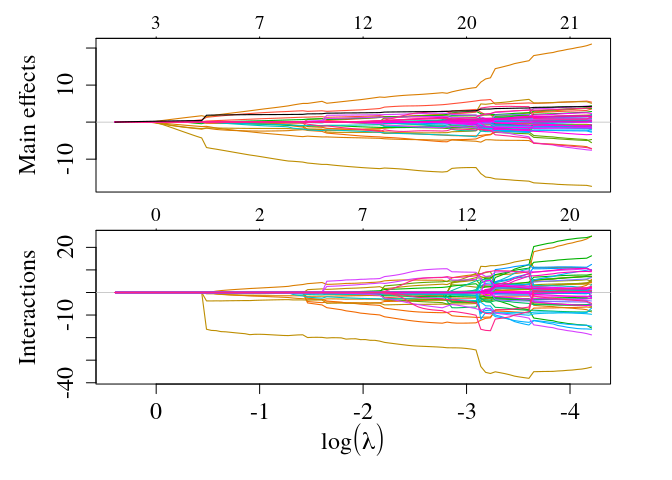

```r
plot(fit)
```

The estimated coefficients at each value of lambda is given by (matrix partially printed here for brevity)

```r
coef(fit)[1:6,50:55]
```

```
#> 6 x 6 sparse Matrix of class "dgCMatrix"
#>                    s50        s51        s52        s53       s54
#> (Intercept)  5.3445152  5.3350735  5.3260684  5.3209183  5.314509
#> X1_1         0.7668023  0.8407632  0.9134418  0.9963138  1.085707
#> X1_2         1.4682908  1.5072192  1.5402298  1.5855723  1.652733
#> X1_3         3.1982020  3.2553440  3.3051339  3.3837769  3.485491
#> X2_1        -3.5192313 -3.6285818 -3.7307130 -3.8183660 -3.881222
#> X2_2        -1.8958170 -1.8899979 -1.8853574 -1.8738510 -1.860779
#>                   s55
#> (Intercept)  5.310267
#> X1_1         1.173776
#> X1_2         1.705634
#> X1_3         3.572614
#> X2_1        -3.949365
#> X2_2        -1.845185
```

The predicted response at each value of lambda:

```r
predict(fit)[1:5,50:55]
```

```
#>             s50        s51        s52        s53        s54        s55
#> [1,]  5.7445034  5.7179456  5.6497326  5.6215581  5.5483312  5.5167354
#> [2,]  3.5886152  3.6608123  3.6673009  3.7788863  3.8397710  3.9364845
#> [3,]  0.7525327  0.7083256  0.6460716  0.6605192  0.6352286  0.6510435
#> [4,] 12.5038372 12.4852941 12.5806330 12.5278481 12.5857507 12.5421780
#> [5,]  1.3865576  1.3339420  1.3466244  1.3138336  1.3409284  1.3203384
```

The predicted response at a specific value of lambda can be specified by the `s` argument:

```r
predict(fit, s = 0.8)
```

```
#>               1
#>   [1,] 5.565188
#>   [2,] 5.245648
#>   [3,] 4.256588
#>   [4,] 6.314703
#>   [5,] 3.884374
#>   [6,] 4.446973
#>   [7,] 6.112132
#>   [8,] 5.360375
#>   [9,] 5.972536
#>  [10,] 5.558947
#>  [11,] 5.252652
#>  [12,] 6.394977
#>  [13,] 6.304268
#>  [14,] 4.993944
```

[output cut: 86 more lines]

You can specify more than one value for `s`:

```r
predict(fit, s = c(0.8, 0.2))
```

```
#>               1          2
#>   [1,] 5.565188  6.4563490
#>   [2,] 5.245648  3.5762830
#>   [3,] 4.256588  1.2541443
#>   [4,] 6.314703 12.3815143
#>   [5,] 3.884374  1.5612304
#>   [6,] 4.446973  1.5503816
#>   [7,] 6.112132 12.6330145
#>   [8,] 5.360375  6.4671028
#>   [9,] 5.972536  7.0190070
#>  [10,] 5.558947  5.2948898
#>  [11,] 5.252652  4.3677887
#>  [12,] 6.394977 11.2278283
#>  [13,] 6.304268 11.6189806
#>  [14,] 4.993944  4.0124434
```

[output cut: 86 more lines]

You can also extract a list of active variables (i.e. variables with a non-zero estimated coefficient) for each value of lambda:

```r
fit[["active"]]
```

```
#> [[1]]
#> character(0)
#>
#> [[2]]
#> [1] "E"
#>
#> [[3]]
#> [1] "E"
#>
#> [[4]]
#> [1] "E"
#>
#> [[5]]
#> [1] "E"
#>
#> [[6]]
#> [1] "E"
#>
#> [[7]]
#> [1] "E"
#>
#> [[8]]
#> [1] "E"
#>
#> [[9]]
#> [1] "X3" "E"
#>
#> [[10]]
#> [1] "X3" "X4" "E"
#>
#> [[11]]
#> [1] "X3" "X4" "E"
#>
#> [[12]]
#> [1] "X3" "X4" "E"
#>
#> [[13]]
#> [1] "X3" "X4" "E"
#>
#> [[14]]
```

[output cut: 443 more lines]

```
#> [[99]]
#>  [1] "X1"    "X2"    "X3"    "X4"    "X5"    "X6"    "X7"    "X8"
#>  [9] "X9"    "X10"   "X11"   "X12"   "X13"   "X14"   "X15"   "X16"
#> [17] "X17"   "X18"   "X19"   "X20"   "X1:E"  "X2:E"  "X3:E"  "X4:E"
#> [25] "X5:E"  "X6:E"  "X7:E"  "X8:E"  "X9:E"  "X10:E" "X11:E" "X12:E"
#> [33] "X13:E" "X14:E" "X15:E" "X16:E" "X17:E" "X18:E" "X19:E" "X20:E"
#> [41] "E"
#>
#> [[100]]
#>  [1] "X1"    "X2"    "X3"    "X4"    "X5"    "X6"    "X7"    "X8"
#>  [9] "X9"    "X10"   "X11"   "X12"   "X13"   "X14"   "X15"   "X16"
#> [17] "X17"   "X18"   "X19"   "X20"   "X1:E"  "X2:E"  "X3:E"  "X4:E"
#> [25] "X5:E"  "X6:E"  "X7:E"  "X8:E"  "X9:E"  "X10:E" "X11:E" "X12:E"
#> [33] "X13:E" "X14:E" "X15:E" "X16:E" "X17:E" "X18:E" "X19:E" "X20:E"
#> [41] "E"
```

## Cross-Validation

`cv.sail` is the main function to do cross-validation along with `plot`, `predict`, and `coef` methods for objects of class `cv.sail`. We can also run it in parallel:

```r
set.seed(432) # to reproduce results (randomness due to CV folds)
library(doParallel)
registerDoParallel(cores = 2)
cvfit <- cv.sail(x = sailsim$x, y = sailsim$y, e = sailsim$e, basis = f.basis,
                 dfmax = 10, # to speed up vignette build time
                 nfolds = 5, parallel = TRUE, nlambda = 50)
```

We plot the cross-validated error curve which has the mean-squared error on the y-axis and $\log(\lambda)$ on the x-axis. It includes the cross-validation curve (red dotted line), and upper and lower standard deviation curves along the $\lambda$ sequence (error bars). Two selected $\lambda$’s are indicated by the vertical dotted lines (see below). The numbers at the top of the plot represent the total number of non-zero variables at that value of $\lambda$ (`df_main` + `df_environment` + `df_interaction`):

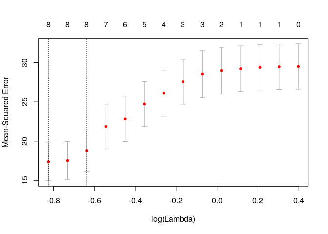

```r
plot(cvfit)
```

`lambda.min` is the value of $\lambda$ that gives minimum mean cross-validated error. The other $\lambda$ saved is `lambda.1se`, which gives the most regularized model such that error is within one standard error of the minimum. We can view the selected $\lambda$’s and the corresponding coefficients:

```r
cvfit[["lambda.min"]]
```

```
#> [1] 0.4385394
```

```r
cvfit[["lambda.1se"]]
```

```
#> [1] 0.5292261
```

The estimated coefficients at `lambda.1se` and `lambda.min`:

```r
cbind(coef(cvfit, s="lambda.1se"), # lambda.1se is the default
coef(cvfit, s = "lambda.min"))
```

```
#> 122 x 2 sparse Matrix of class "dgCMatrix"
#>                        1           1
#> (Intercept)   5.44728244   5.4489968
#> X1_1         -0.33479902  -0.3475998
#> X1_2          0.46732277   0.6911858
#> X1_3          1.70401603   2.1622040
#> X2_1          .            .
#> X2_2          .            .
#> X2_3          .            .
#> X3_1          2.12553380   2.7746062
#> X3_2         -1.81057790  -2.3950334
#> X3_3         -2.10280952  -2.3355539
#> X4_1         -0.26919665  -0.2769379
#> X4_2         -7.58248628  -8.4137355
#> X4_3         -1.62272272  -1.6547066
#> X5_1          .            .
#> X5_2          .            .
#> X5_3          .            .
#> X6_1          .            .
#> X6_2          .            .
#> X6_3          .            .
#> X7_1          .            .
#> X7_2          .            .
#> X7_3          .            .
#> X8_1          0.07611936   0.2212063
#> X8_2         -0.01517658  -0.0426662
#> X8_3         -0.12663659  -0.3606695
#> X9_1          .            .
#> X9_2          .            .
#> X9_3          .            .
#> X10_1         .            .
#> X10_2         .            .
#> X10_3         .            .
#> X11_1         0.06458267   0.1329899
#> X11_2        -0.13771228  -0.3428515
#> X11_3        -0.26279204  -0.6303841
#> X12_1         .            .
#> X12_2         .            .
#> X12_3         .            .
#> X13_1         .            .
```

[output cut: 69 more lines]

```
#> X16_1:E       .            .
#> X16_2:E       .            .
#> X16_3:E       .            .
#> X17_1:E       .            .
#> X17_2:E       .            .
#> X17_3:E       .            .
#> X18_1:E       .            .
#> X18_2:E       .            .
#> X18_3:E       .            .
#> X19_1:E       .            .
#> X19_2:E       .            .
#> X19_3:E       .            .
#> X20_1:E       .            .
#> X20_2:E       .            .
#> X20_3:E       .            .
```

Estimated non-zero coefficients at `lambda.1se`:

```r
predict(cvfit, type = "nonzero")
```

```
#>                        1
#> (Intercept)   5.44728244
#> X1_1         -0.33479902
#> X1_2          0.46732277
#> X1_3          1.70401603
#> X3_1          2.12553380
#> X3_2         -1.81057790
#> X3_3         -2.10280952
#> X4_1         -0.26919665
#> X4_2         -7.58248628
#> X4_3         -1.62272272
#> X8_1          0.07611936
#> X8_2         -0.01517658
#> X8_3         -0.12663659
#> X11_1         0.06458267
#> X11_2        -0.13771228
#> X11_3        -0.26279204
#> E             1.94035362
#> X3_1:E        0.89039027
#> X3_2:E       -0.75845463
#> X3_3:E       -0.88087103
#> X4_1:E       -0.61790227
#> X4_2:E      -17.40450905
#> X4_3:E       -3.72472712
```

## Visualizing the Effect of the Non-linear Terms

bsplines are difficult to interpret. We provide a plotting function to visualize the effect of the non-linear function on the response.

### Main Effects

Since we are using simulated data, we also plot the true curve:

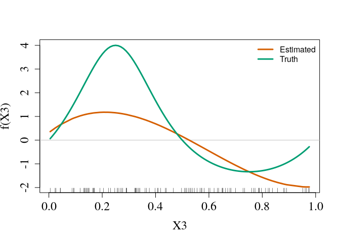

```r
plotMain(cvfit$sail.fit, x = sailsim$x, xvar = "X3",
         legend.position = "topright",
         s = cvfit$lambda.min, f.truth = sailsim$f3)
```

### Interaction Effects

Again, since we are using simulated data, we also plot the true interaction:

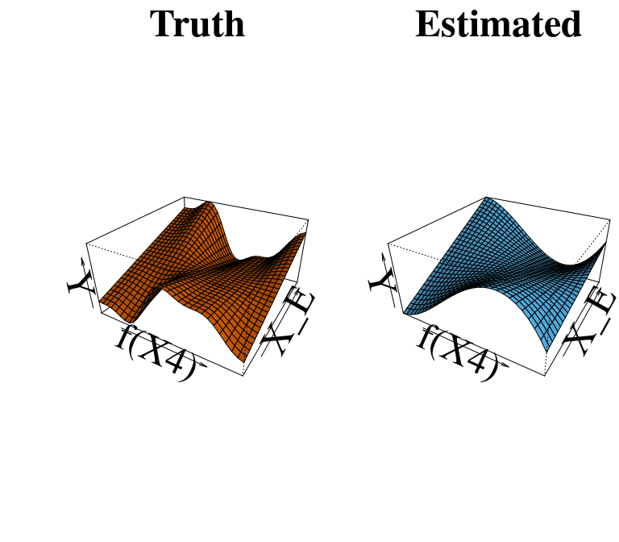

```r
plotInter(cvfit$sail.fit, x = sailsim$x, xvar = "X4",
          f.truth = sailsim$f4.inter,
          s = cvfit$lambda.min,
          title_z = "Estimated")
```

## Linear Interactions

The `basis` argument in the `sail` function is very flexible in that it allows you to apply **any** basis expansion to the columns of $\mathbf{X}$. Of course, there might be situations where you do not expect any non-linear main effects or interactions to be present in your data. You can still use the `sail` method to search for **linear** main effects and interactions. This can be accomplished by specifying an identity map:

```r
f.identity <- function(i) i
```

We then pass this function to `basis` argument in `cv.sail`:

```r
cvfit_linear <- cv.sail(x = sailsim$x, y = sailsim$y, e = sailsim$e,
                        basis = f.identity, nfolds = 5, parallel = TRUE,
                 dfmax = 10, # to speed up vignette build time
                        nlambda = 50)
```

Next we plot the cross-validated curve:

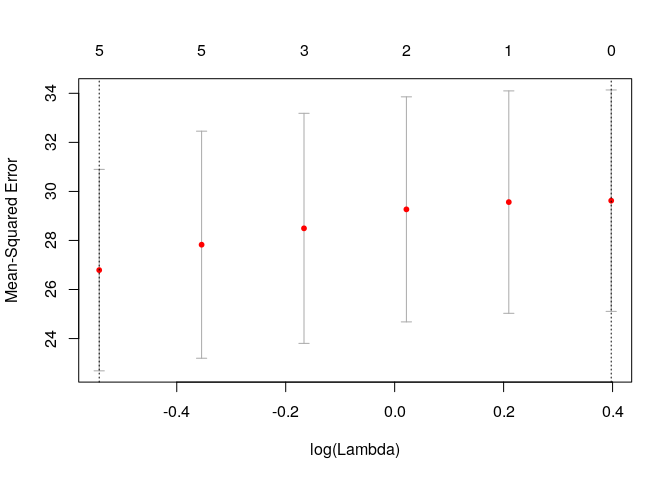

```r
plot(cvfit_linear)
```

And extract the model at `lambda.min`:

```r
coef(cvfit_linear, s = "lambda.min")
```

```
#> 42 x 1 sparse Matrix of class "dgCMatrix"
#>                      1
#> (Intercept)  5.2789845
#> X1_1         0.6445908
#> X2_1         .
#> X3_1        -2.0254507
#> X4_1        -3.2233978
#> X5_1         .
#> X6_1         .
#> X7_1         .
#> X8_1         .
#> X9_1         .
#> X10_1        .
#> X11_1       -1.4226233
#> X12_1        .
#> X13_1        .
#> X14_1        .
#> X15_1        .
#> X16_1        .
#> X17_1        .
#> X18_1        .
#> X19_1        .
#> X20_1        .
#> E            0.4723233
#> X1_1:E       .
#> X2_1:E       .
#> X3_1:E       .
#> X4_1:E       .
#> X5_1:E       .
#> X6_1:E       .
#> X7_1:E       .
#> X8_1:E       .
#> X9_1:E       .
#> X10_1:E      .
#> X11_1:E      .
#> X12_1:E      .
#> X13_1:E      .
#> X14_1:E      .
#> X15_1:E      .
#> X16_1:E      .
#> X17_1:E      .
#> X18_1:E      .
#> X19_1:E      .
#> X20_1:E      .
```

## Applying a different penalty to each predictor

Recall that we consider the following penalized least squares criterion for this problem:

$$\begin{equation}
\arg\min_{\boldsymbol{\theta} } \mathcal{L}(Y;\boldsymbol{\theta}) + \lambda (1-\alpha) \left( w_E |\beta_E| + \sum_{j=1}^{p} w_j \lVert\boldsymbol{\theta}_j \rVert_2 \right) + \lambda\alpha \sum_{j=1}^{p} w_{jE} |\gamma_{j}|
\end{equation}$$

The weights $w_E, w_j, w_{jE}$ are by default set to 1 as specified by the `penalty.factor` argument. This argument allows users to apply separate penalty factors to each coefficient. In particular, any variable with `penalty.factor` equal to zero is not penalized at all. This feature can be applied mainly for two reasons:

1. Prior knowledge about the importance of certain variables is known. Larger weights will penalize the variable more, while smaller weights will penalize the variable less
2. Allows users to apply the Adaptive `sail`, similar to the [Adaptive Lasso](http://users.stat.umn.edu/~zouxx019/Papers/adalasso.pdf)

In the following example, we want the environment variable to always be included so we set the first element of `p.fac` to zero. We also want to apply less of a penalty to the main effects for $X_2, X_3, X_4$:

```r
# the weights correspond to E, X1, X2, X3, ... X_p, X1:E, X2:E, ... X_p:E
p.fac <- c(0, 1, 0.4, 0.6, 0.7, rep(1, 2*ncol(sailsim$x) - 4))
```

```r
fit_pf <- sail(x = sailsim$x, y = sailsim$y, e = sailsim$e, basis = f.basis,
               nlambda = 50,
               dfmax = 10, # to speed up vignette build time
               penalty.factor = p.fac)
```

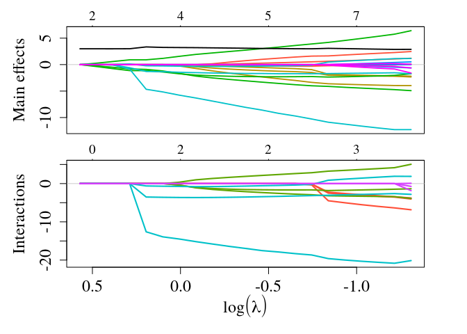

```r
plot(fit_pf)
```

We see from the plot above that the black line (corresponding to the $E$ variable with `penalty.factor` equal to zero) is always included in the model.